# ANA 515 - Assignment 2 - Storm Event Analysis

Shanmugapriya Mohan Kumar

2024-06-24

## Objective

The objective of this analysis is to process and visualize storm events data from a provided CSV file.

1. Filter the storm events data to include only events listed by county FIPS.
2. Format the state and county FIPS codes and combine them into a single FIPS column.
3. Standardize all column names to lower case for consistency.
4. Integrate state-level information, including area and region, from built-in R datasets.
5. Calculate the number of storm events per state.
6. Merge the storm events data with state information, ensuring only matching states are included.
7. Display the merged data in a comprehensive table.
8. Create a scatter plot to visualize the relationship between land area and the number of storm events, with points color-coded by region.

Through this analysis, we aim to gain insights into the distribution and frequency of storm events across different states and regions, and how these events correlate with the geographic area of the states.

### Load and display data

```
The table contains 8725 rows and 51 variables.
```

```
## # A tibble: 6 × 51
##   BEGIN_YEARMONTH BEGIN_DAY BEGIN_TIME END_YEARMONTH END_DAY END_TIME EPISODE_ID
##             <dbl>     <dbl>      <dbl>         <dbl>   <dbl>    <dbl> <lgl>
## 1          198603        16        145        198603      16      145 NA
## 2          198609        18       2020        198609      18     2020 NA
## 3          198610        21       1622        198610      21     1622 NA
## 4          198604        11       2130        198604      11     2130 NA
## 5          198608        16       1430        198608      16     1430 NA
## 6          198604         7         30        198604       7       30 NA
## # ℹ 44 more variables: EVENT_ID <dbl>, STATE <chr>, STATE_FIPS <dbl>,
## #   YEAR <dbl>, MONTH_NAME <chr>, EVENT_TYPE <chr>, CZ_TYPE <chr>,
## #   CZ_FIPS <dbl>, CZ_NAME <chr>, WFO <chr>, BEGIN_DATE_TIME <chr>,
## #   CZ_TIMEZONE <chr>, END_DATE_TIME <chr>, INJURIES_DIRECT <dbl>,
## #   INJURIES_INDIRECT <dbl>, DEATHS_DIRECT <dbl>, DEATHS_INDIRECT <dbl>,
## #   DAMAGE_PROPERTY <chr>, DAMAGE_CROPS <dbl>, SOURCE <lgl>, MAGNITUDE <dbl>,
## #   MAGNITUDE_TYPE <lgl>, FLOOD_CAUSE <lgl>, CATEGORY <lgl>, …
```

# Limit the dataframe to the selected columns

```
## # A tibble: 6 × 8
##   BEGIN_YEARMONTH EPISODE_ID STATE STATE_FIPS CZ_NAME CZ_TYPE CZ_FIPS EVENT_TYPE
##             <dbl> <lgl>      <chr>      <dbl> <chr>   <chr>     <dbl> <chr>
## 1          198603 NA         ALAB…          1 LOWNDES C            85 Hail
## 2          198609 NA         COLO…          8 WASHIN… C           121 Hail
## 3          198610 NA         COLO…          8 ARAPAH… C             5 Hail
## 4          198604 NA         ARKA…          5 COLUMB… C            27 Hail
## 5          198608 NA         ALAB…          1 MORGAN  C           103 Thunderst…
## 6          198604 NA         MISS…         29 HICKORY C            85 Hail
```

# Arrange the dataframe by the state name

```
## # A tibble: 6 × 8
##   BEGIN_YEARMONTH EPISODE_ID STATE STATE_FIPS CZ_NAME CZ_TYPE CZ_FIPS EVENT_TYPE
##             <dbl> <lgl>      <chr>      <dbl> <chr>   <chr>     <dbl> <chr>
## 1          198603 NA         ALAB…          1 LOWNDES C            85 Hail
## 2          198608 NA         ALAB…          1 MORGAN  C           103 Thunderst…
## 3          198602 NA         ALAB…          1 MARSHA… C            95 Thunderst…
## 4          198602 NA         ALAB…          1 CHEROK… C            19 Thunderst…
## 5          198602 NA         ALAB…          1 SUMTER  C           119 Thunderst…
## 6          198602 NA         ALAB…          1 SUMTER  C           119 Hail
```

## Arrange the stormdata by converting state and county name to Titlecase

```
## # A tibble: 6 × 8
##   BEGIN_YEARMONTH EPISODE_ID STATE STATE_FIPS CZ_NAME CZ_TYPE CZ_FIPS EVENT_TYPE
##             <dbl> <lgl>      <chr>      <dbl> <chr>   <chr>     <dbl> <chr>
## 1          198603 NA         Alab…          1 Lowndes C            85 Hail
## 2          198608 NA         Alab…          1 Morgan  C           103 Thunderst…
## 3          198602 NA         Alab…          1 Marsha… C            95 Thunderst…
## 4          198602 NA         Alab…          1 Cherok… C            19 Thunderst…
## 5          198602 NA         Alab…          1 Sumter  C           119 Thunderst…
## 6          198602 NA         Alab…          1 Sumter  C           119 Hail
```

## Filter the storm events data to include only events listed by county FIPS.

The filtered data frame has 8725 rows.

```
## # A tibble: 6 × 7
##   BEGIN_YEARMONTH EPISODE_ID STATE   STATE_FIPS CZ_NAME  CZ_FIPS EVENT_TYPE
##             <dbl> <lgl>      <chr>        <dbl> <chr>      <dbl> <chr>
## 1          198603 NA         Alabama          1 Lowndes       85 Hail
## 2          198608 NA         Alabama          1 Morgan       103 Thunderstorm W…
## 3          198602 NA         Alabama          1 Marshall      95 Thunderstorm W…
## 4          198602 NA         Alabama          1 Cherokee      19 Thunderstorm W…
## 5          198602 NA         Alabama          1 Sumter       119 Thunderstorm W…
## 6          198602 NA         Alabama          1 Sumter       119 Hail
```

## Unite the state and county FIPS into one FIPS column

```
## # A tibble: 6 × 6
##   BEGIN_YEARMONTH EPISODE_ID STATE   FIPS   CZ_NAME  EVENT_TYPE
##             <dbl> <lgl>      <chr>   <chr>  <chr>    <chr>
## 1          198603 NA         Alabama 001085 Lowndes  Hail
## 2          198608 NA         Alabama 001103 Morgan   Thunderstorm Wind
## 3          198602 NA         Alabama 001095 Marshall Thunderstorm Wind
## 4          198602 NA         Alabama 001019 Cherokee Thunderstorm Wind
## 5          198602 NA         Alabama 001119 Sumter   Thunderstorm Wind
## 6          198602 NA         Alabama 001119 Sumter   Hail
```

## Display the first few rows of the dataframe with lower case column names

```
## # A tibble: 6 × 6
##   begin_yearmonth episode_id state   fips   cz_name  event_type
##             <dbl> <lgl>      <chr>   <chr>  <chr>    <chr>
## 1          198603 NA         Alabama 001085 Lowndes  Hail
## 2          198608 NA         Alabama 001103 Morgan   Thunderstorm Wind
## 3          198602 NA         Alabama 001095 Marshall Thunderstorm Wind
## 4          198602 NA         Alabama 001019 Cherokee Thunderstorm Wind
## 5          198602 NA         Alabama 001119 Sumter   Thunderstorm Wind
## 6          198602 NA         Alabama 001119 Sumter   Hail
```

## US State name, Area and Region

```
##     US_State   Area Region
## 1    Alabama  51609  South
## 2     Alaska 589757   West
## 3    Arizona 113909   West
## 4   Arkansas  53104  South
## 5 California 158693   West
## 6   Colorado 104247   West
```

## The number of storm events per state

```
## # A tibble: 6 × 2
##   state       number_of_events
##   <chr>                  <int>
## 1 Alabama                  266
## 2 Arizona                   61
## 3 Arkansas                 281
## 4 California                23
## 5 Colorado                 127
## 6 Connecticut                2
```

## Integrate state-level information, including area and region, from built-in R datasets.

| state | number_of_events | Area | Region |
| --- | --- | --- | --- |
| Alabama | 266 | 51609 | South |
| Arizona | 61 | 113909 | West |
| Arkansas | 281 | 53104 | South |
| California | 23 | 158693 | West |
| Colorado | 127 | 104247 | West |
| Connecticut | 2 | 5009 | Northeast |
| Delaware | 3 | 2057 | South |
| Florida | 186 | 58560 | South |
| Georgia | 232 | 58876 | South |
| Hawaii | 2 | 6450 | West |
| Idaho | 25 | 83557 | West |
| Illinois | 211 | 56400 | North Central |
| Indiana | 274 | 36291 | North Central |
| Iowa | 358 | 56290 | North Central |
| Kansas | 664 | 82264 | North Central |
| Kentucky | 164 | 40395 | South |
| Louisiana | 139 | 48523 | South |
| Maine | 64 | 33215 | Northeast |
| Maryland | 28 | 10577 | South |
| Massachusetts | 18 | 8257 | Northeast |
| Michigan | 168 | 58216 | North Central |
| Minnesota | 203 | 84068 | North Central |
| Mississippi | 193 | 47716 | South |
| Missouri | 204 | 69686 | North Central |
| Montana | 27 | 147138 | West |
| Nebraska | 409 | 77227 | North Central |
| Nevada | 9 | 110540 | West |
| New Hampshire | 52 | 9304 | Northeast |
| New Jersey | 13 | 7836 | Northeast |
| New Mexico | 22 | 121666 | West |
| New York | 240 | 49576 | Northeast |
| North Carolina | 392 | 52586 | South |
| North Dakota | 180 | 70665 | North Central |
| Ohio | 303 | 41222 | North Central |
| Oklahoma | 1055 | 69919 | South |
| Oregon | 1 | 96981 | West |
| Pennsylvania | 228 | 45333 | Northeast |
| Rhode Island | 4 | 1214 | Northeast |
| South Carolina | 121 | 31055 | South |
| South Dakota | 238 | 77047 | North Central |
| Tennessee | 93 | 42244 | South |
| Texas | 1018 | 267339 | South |
| Utah | 29 | 84916 | West |
| Vermont | 51 | 9609 | Northeast |
| Virginia | 62 | 40815 | South |
| Washington | 3 | 68192 | West |
| West Virginia | 44 | 24181 | South |
| Wisconsin | 145 | 56154 | North Central |
| Wyoming | 89 | 97914 | West |

### Visualization

This Scatter plot is to visualize the relationship between land area and the number of storm events, with points color-coded by region.

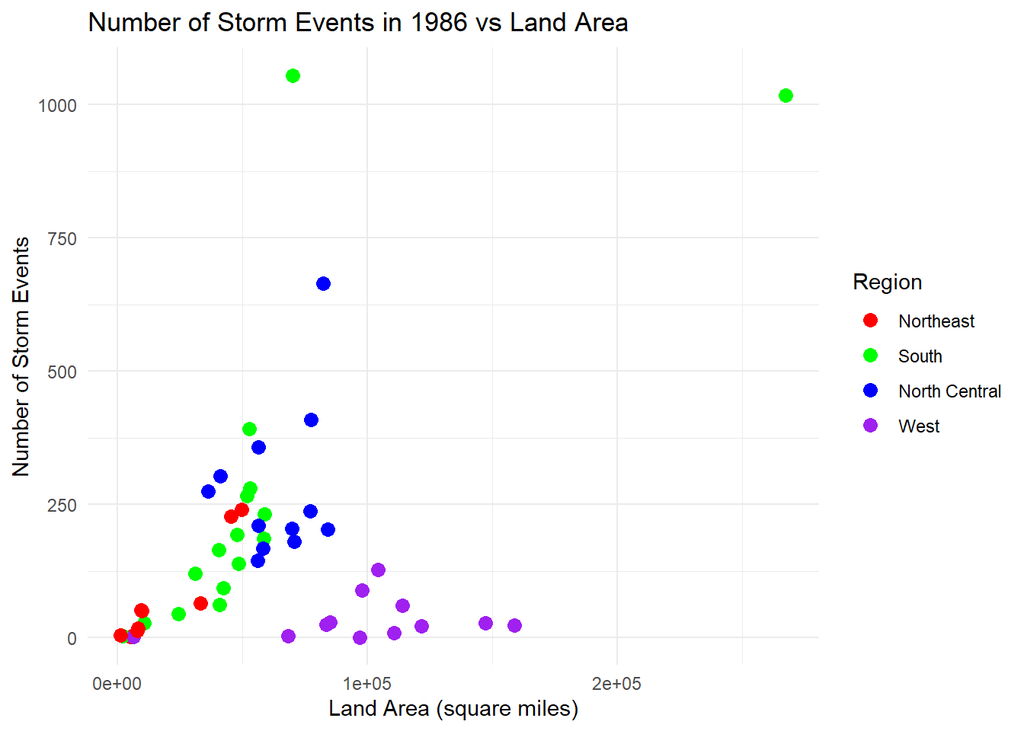